# Rでクマ出没地図を作成しよう

Kanazawa.R #6

作者

伊東宏樹

公開

2026年11月28日

## はじめに

このチュートリアルでは、Rのleafletパッケージをつかった地図の表示方法について説明します。題材として、石川県のクマ出没情報を用い、その位置を地図上にプロットすることを目的とします。

※ Quartoのソースファイルは、GitHubのリポジトリKanazawaR006にて公開しています。

## 準備

tidyverseパッケージを読み込みます。また、地図表示のためleafletパッケージを使用します。

グラフのフォントにはNoto Sans JPを使用しています。適宜お好みのフォントに変更してください。

```r
library(tidyverse)
library(leaflet)

jp_font <- "Noto Sans JP"
# jp_font <- "Yu Gothic"  # 游ゴシック体を使うなら
```

## データ

データとして、[いしかわオープンデータカタログ](https://front.opendata.pref.ishikawa.lg.jp)にある[石川県クマ出没データ](https://ckan.opendata.pref.ishikawa.lg.jp/dataset/bear_incidents_data)を使用します。

### データファイル

上のサイトから、以下の6つのデータ（CSV形式）をダウンロードしておきます。

- R7 ツキノワグマ目撃・痕跡情報- R7目撃情報
- 石川県クマ出没分析マップ（R1〜R6）- (1)森林からの出没（R1-R6)
- 石川県クマ出没分析マップ（R1〜R6）- (2)河川からの出没（R1-R6)
- 石川県クマ出没分析マップ（R1〜R6）- (3)誘引物が要因の出没（R1-R6)
- 石川県クマ出没分析マップ（R1〜R6）- (4)親離れした若クマによる出没（R1-R6)
- 石川県クマ出没分析マップ（R1〜R6）- (5)大量出没年に特有の出没（R2)

ダウンロードしたデータは`kuma_data`ディレクトリに入れておきます。

`data_files`という文字列ベクトルに各ファイルのパスを格納しておきます。

```r
data_files <- c(
  "kuma_data/7584d555-e1f8-4639-b62d-919445970236.csv",
  "kuma_data/bear_incidents_forest_r1-r6.csv",
  "kuma_data/bear_incidents_river_r1-r6.csv",
  "kuma_data/bear_incidents_attractants_r1-r6.csv",
  "kuma_data/bear_incidents_young_bears_r1-r6.csv",
  "kuma_data/bear_incidents_mass_outbreak_r2.csv"
)
```

### データ読み込み

今回のデータは、一見したところTidy data（整然データ）のようになっています。ただし、2024年以前のデータは、同じ種類の観測が複数の表になっています（Tidy dataの[条件](https://id.fnshr.info/2017/01/09/tidy-data-intro/#toc-heading-1)のひとつ「個々の観測の構成単位の類型が1つの表をなす」に反する）。

また、2025年と2024年以前とでは形式が異なります。さらに、いくつかの項目では追加の処理が必要になります。このため、それぞれに読み込み用の関数を定義します。

データのクリーニングや前処理の際には一般に、元のデータファイルは書き換えず、読み込み処理や前処理で対応するのが望ましいとされています。今回も元のデータファイルは変更せずに、Rの処理でなんとかします。

#### 2025年用読み込み関数

まず、2025年用の関数です。時刻は、分は無視して、時単位の数値データとしました（最初の数値だけ見る）。時刻が「17時30分～19時頃」のように時間帯で記されている場合は、始点の時刻としました。

また、`show_col_types = FALSE`と指定して、`read_csv()`関数の列型の自動判定のメッセージを抑制しています。

```r
# 2025年のデータを読み込む
read_data_2025 <- function(file) {
  d <- read_csv(file, show_col_types = FALSE) |>
    dplyr::mutate(ID = str_c("2025-", as.character(`_id`)),
                  Year = 2025,
                  Date = ymd(`出没日`),
                  Month = month(Date),
                  # 時刻:
                  Time = stringi::stri_trans_nfkc(`時間`),  # 正規化
                  Hour = str_extract(Time, "\\d+") |> as.numeric(),
                  # 頭数: 正規化のうえ数値を抜きだして、数値型にします
                  Num = stringi::stri_trans_nfkc(`頭数`) |>
                    str_extract("\\d+") |>
                    as.numeric()) |>
    dplyr::rename(Latitude = `緯度`,
                  Longitude = `経度`,
                  City = `市町名`,
                  Location = `場所`,
                  Note = `備考`) |>
    dplyr::select(ID, Latitude, Longitude,
                  Date, Time, Year, Month, Hour,
                  City, Location, Note, Num)
}
```

#### 2019-2024年用読み込み関数

2019-2024年用の関数です。2025年のデータと列名や形式が異なるため、別の関数にしています。主な違いは次のとおりです。

- `出没年`が元号ローマ字+年表記（“R1”〜“R6”）なので、想定外の形式がないかを最初にチェックし、あれば`stop()`でエラーにします。その後、西暦（令和の年 + 2018）に変換します。
- `出没日`は、Excelのシリアル値（例: 43800）、“R1.5.3”のような元号ローマ字表記、“2019/5/3”のような西暦表記が混在しているため、`case_when()`で形式ごとに処理します。どれにも当てはまらないものは欠損値になります。
- IDは年ごとに連番が振られていて他の年と重なる可能性があるため、先頭に年をつけます。

```r
# 2019-2024年
read_data_2019 <- function(file) {
  d <- read_csv(file, show_col_types = FALSE)

  # `出没年` が "R1"〜"R6" の形式かチェック
  bad <- d |>
    dplyr::filter(!str_detect(`出没年`, "^R[1-6]$"))
  if (nrow(bad) > 0) {
    stop(sprintf("%s: `出没年`が想定外の形式の行が %d 件あります: %s",
                 file, nrow(bad),
                 paste(unique(bad$`出没年`), collapse = ", ")))
  }

  d <- d |>
    dplyr::mutate(
      # 出没年: "R1, R2, ..." を西暦に変換します
      # 2文字目を数値に変換して2018をたします
      Year = as.numeric(str_sub(`出没年`, 2)) + 2018,
      # 日付:
      Date = case_when(
        # Excelのシリアル値の場合
        str_detect(`出没日`, "^4[0-9]{4}$") ~
          # Excelの起点は1899-12-30です
          as.Date(as.numeric(`出没日`), origin = "1899-12-30"),
        # "R1..."という形式の場合
        str_detect(`出没日`, "^R[1-9]") ~
          # 元号を西暦に置換してからymd()関数にわたします
          str_replace(`出没日`, "^R[1-9]",
                      as.character(Year)) |>
          ymd(),
        # "2019...""という形式の場合
        str_detect(`出没日`, "^2[0-9]{3}") ~
          # そのままymd()関数にわたします
          ymd(`出没日`),
        # その他は欠損値に
        TRUE ~ as.Date(NA)),
      # 月:
      Month = month(Date),
      # 時刻:
      Time = stringi::stri_trans_nfkc(`時刻`),  # 正規化
      Hour = str_extract(Time, "\\d+") |> as.numeric(),
      # 頭数: 正規化のうえ数値を抜きだして、数値型にします
      Num = stringi::stri_trans_nfkc(`頭数`) |>
            str_extract("\\d+") |>
            as.numeric(),
      # ID: 年を先頭につけます
      ID = sprintf("%d-%s", Year, as.character(`ID`)))

  # `出没年` と `出没日` の年に矛盾がないかチェック
  # 元号表記の日付は元号の年から、それ以外は変換後の日付から年を求める
  bad <- d |>
    dplyr::mutate(
      Year_date = if_else(
        str_detect(`出没日`, "^R[1-9]"),
        as.numeric(str_extract(`出没日`, "(?<=^R)[1-9]")) + 2018,
        year(Date))) |>
    dplyr::filter(!is.na(Year_date), Year_date != Year)
  if (nrow(bad) > 0) {
    stop(sprintf("%s: `出没年`と`出没日`の年が矛盾する行が %d 件あります (ID: %s)",
                 file, nrow(bad),
                 paste(head(bad$ID, 5), collapse = ", ")))
  }

  d <- d |>
    dplyr::rename(Latitude = `緯度`,
                  Longitude = `経度`,
                  City = `市町名`,
                  Location = `場所`,
                  Note = `備考`) |>
    dplyr::select(ID, Latitude, Longitude,
                  Date, Time, Year, Month, Hour,
                  City, Location, Note, Num)
}
```

ためしに、2019年のファイル(`kuma_data/bear_incidents_forest_r1-r6.csv`)で関数の動作を確認します。警告が出ますが、これは`出没日`がExcelのシリアル値の場合の処理が、`case_when()`関数の仕様として、いったんすべての値に対しておこなわれるためで、問題はありません。

```r
read_data_2019(data_files[2])
```

```
Warning: There were 2 warnings in `dplyr::mutate()`.
The first warning was:
ℹ In argument: `Date = case_when(...)`.
Caused by warning in `as.Date()`:
! 強制変換により NA が生成されました
ℹ Run `dplyr::last_dplyr_warnings()` to see the 1 remaining warning.
```

#### 読み込み処理

実際に各年のデータを読み込みます。ここでも警告がでますが、問題はありません。

```r
data_list <- purrr::map(
  data_files,
  \(f) if (f == data_files[1])  # 2025年
         read_data_2025(f)
       else                     # 2025年以外
         read_data_2019(f)
)
```

[output not shown]

```
Warning: There were 3 warnings in `dplyr::mutate()`.
The first warning was:
ℹ In argument: `Date = case_when(...)`.
Caused by warning in `as.Date()`:
! 強制変換により NA が生成されました
ℹ Run `dplyr::last_dplyr_warnings()` to see the 2 remaining warnings.
```

```
Warning: There were 2 warnings in `dplyr::mutate()`.
The first warning was:
ℹ In argument: `Date = case_when(...)`.
Caused by warning in `as.Date()`:
! 強制変換により NA が生成されました
ℹ Run `dplyr::last_dplyr_warnings()` to see the 1 remaining warning.
```

読み込んだ行数を表示します。異常な数値でないことを確認します。

```r
purrr::map_int(data_list, nrow)
```

```
[1]  103 2423  390  273  467  245
```

なお、ファイルをダウンロードせずに、サイトのAPIを利用して直接読み込むことも可能です（ここでは例示だけです）。

```r
library(httr2)

base_url <- "https://ckan.opendata.pref.ishikawa.lg.jp/api/3/action/datastore_search"

fetch_page <- function(offset, limit = 1000) {
  request(base_url) |>
    req_url_query(resource_id = "8f01fa0b-704f-4d34-a53b-42d481cf885c",
                  limit = limit, offset = offset) |>
    req_perform() |>
    resp_body_json()
}

first <- fetch_page(0)
total <- first$result$total
records <- first$result$records
offset <- 1000
while (offset < total) {
  records <- c(records, fetch_page(offset)$result$records)
  offset <- offset + 1000
}

df <- dplyr::bind_rows(records)
```

### 前処理

ファイルは読み込みましたが、実は読んだファイルにはいくつか修正を要する点があります。地図化の前にこれを解決する必要があります。

まず、読み込んだデータを結合します。

```r
data_bind <- bind_rows(data_list)
```

IDに重複がないか確認します。

```r
data_bind |>
  dplyr::pull(ID) |>
  table() |>
  sort(decreasing = TRUE) |>
  head(20)
```

```
2020-1083 2020-1103 2020-1149 2020-1415  2020-655  2020-656  2020-676 2019-2041
        4         4         4         4         4         4         4         3
2019-2084 2020-1064 2020-1065 2020-1068 2020-1074 2020-1118 2020-1127 2020-1139
        3         3         3         3         3         3         3         3
2020-1145 2020-1162 2020-1230 2020-1263
        3         3         3         3
```

重複しているIDのデータのひとつを確認します。

```r
data_bind |>
  dplyr::filter(ID == "2020-1083")
```

```
# A tibble: 4 × 12
  ID        Latitude Longitude Date       Time   Year Month  Hour City  Location
  <chr>        <dbl>     <dbl> <date>     <chr> <dbl> <dbl> <dbl> <chr> <chr>
1 2020-1083     36.4      137. 2020-10-19 19時1…  2020    10    19 能美市…… 能美市鍋谷町地…
2 2020-1083     36.4      137. 2020-10-19 19時1…  2020    10    19 能美市…… 能美市鍋谷町地…
3 2020-1083     36.4      137. 2020-10-19 19時1…  2020    10    19 能美市…… 能美市鍋谷町地…
4 2020-1083     36.4      137. 2020-10-19 19時1…  2020    10    19 能美市…… 能美市鍋谷町地…
# ℹ 2 more variables: Note <chr>, Num <dbl>
```

もうひとつ確認します。

```r
data_bind |>
  dplyr::filter(ID == "2019-2075")
```

```
# A tibble: 2 × 12
  ID        Latitude Longitude Date       Time   Year Month  Hour City  Location
  <chr>        <dbl>     <dbl> <date>     <chr> <dbl> <dbl> <dbl> <chr> <chr>
1 2019-2075     36.4      137. 2019-06-09 15時0…  2019     6    15 能美市…… 能美市鍋谷町……
2 2019-2075     36.4      137. 2019-06-09 15時0…  2019     6    15 能美市…… 能美市鍋谷町……
# ℹ 2 more variables: Note <chr>, Num <dbl>
```

同じデータなので、IDが重複しているデータを`distinct()`関数でまとめようと思います。

まず、IDが同じ行が全列でも同一かどうかを確認します（`0`なら、IDだけで重複を除いても情報が失われません）。

```r
nrow(dplyr::distinct(data_bind, ID)) - nrow(dplyr::distinct(data_bind))
```

```
[1] -14
```

しかし、結果は`0`ではありませんでした。これは、IDが同じで、内容が異なるデータがあることをしめしています。

IDが重複している行のIDを確認します。

```r
data_bind |>
  distinct() |>
  count(ID) |>
  filter(n > 1) |>
  pull(ID)
```

```
 [1] "2019-2075" "2020-1165" "2020-1166" "2020-1280" "2020-688"  "2020-719"
 [7] "2020-755"  "2020-760"  "2020-769"  "2021-1678" "2021-1822" "2022-30"
[13] "2022-32"   "2023-265"
```

ID:2019-2075と2020-1165を表示します。

```r
data_bind |>
  dplyr::filter(ID == "2019-2075" | ID == "2020-1165") |>
  dplyr::arrange(ID)
```

```
# A tibble: 4 × 12
  ID        Latitude Longitude Date       Time   Year Month  Hour City  Location
  <chr>        <dbl>     <dbl> <date>     <chr> <dbl> <dbl> <dbl> <chr> <chr>
1 2019-2075     36.4      137. 2019-06-09 15時0…  2019     6    15 能美市…… 能美市鍋谷町……
2 2019-2075     36.4      137. 2019-06-09 15時0…  2019     6    15 能美市…… 能美市鍋谷町……
3 2020-1165     36.5      137. 2020-10-26 10時0…  2020    10    10 白山市…… 白山市八束……
4 2020-1165     36.5      137. 2020-10-26 10時0…  2020    10    10 白山市…… 白山市八束穂一…
# ℹ 2 more variables: Note <chr>, Num <dbl>
```

ほかも表記揺れや何かの誤りと思われました。そこで、IDが重複しているデータを`distinct()`関数でまとめます。

```r
data_bind <- data_bind |>
  dplyr::distinct(ID, .keep_all = TRUE)
```

再度、重複しているIDがないか確認します。

```r
data_bind |>
  dplyr::pull(ID) |>
  table() |>
  sort(decreasing = TRUE) |>
  head(20)
```

```
2019-2001 2019-2002 2019-2003 2019-2004 2019-2005 2019-2006 2019-2007 2019-2008
        1         1         1         1         1         1         1         1
2019-2010 2019-2011 2019-2012 2019-2013 2019-2014 2019-2015 2019-2016 2019-2017
        1         1         1         1         1         1         1         1
2019-2018 2019-2019 2019-2020 2019-2021
        1         1         1         1
```

なお、もとのデータにはIDが数字ではなく”v”という行がありました。入力ミスの可能性が高いと思われます。2024年以前のデータで、IDに数値以外の文字が含まれている行をチェックします。

```r
purrr::map(
  data_files[-1],
  \(f) read_csv(f, show_col_types = FALSE) |>
    dplyr::filter(str_detect(ID, "^\\d+$", negate = TRUE))
)
```

```
[[1]]
# A tibble: 0 × 16
# ℹ 16 variables: WKT <chr>, ID <dbl>, 目撃痕跡種別 <chr>, 出没年 <chr>,
#   出没日 <chr>, 時刻 <chr>, 市町名 <chr>, 場所 <chr>, 備考 <chr>, 頭数 <chr>,
#   集落 <chr>, 集落コード <dbl>, 500mメッシュコード <dbl>, 緯度 <dbl>,
#   経度 <dbl>, 森林からの出没 <dbl>

[[2]]
# A tibble: 1 × 16
  WKT      ID    目撃痕跡種別 出没年 出没日 時刻  市町名 場所  備考  頭数  集落
  <chr>    <chr> <chr>        <chr>  <chr>  <chr> <chr>  <chr> <chr> <chr> <chr>
1 POINT (… v     目撃         R2     R2.10… 6時15… 加賀市 加賀市小… 賀市小坂… 1     小坂
# ℹ 5 more variables: 集落コード <dbl>, `500mメッシュコード` <dbl>, 緯度 <dbl>,
#   経度 <dbl>, 河川からの出没 <dbl>

[[3]]
# A tibble: 0 × 17
# ℹ 17 variables: WKT <chr>, ID <dbl>, 目撃痕跡種別 <chr>, 出没年 <chr>,
#   出没日 <chr>, 時刻 <chr>, 市町名 <chr>, 場所 <chr>, 備考 <chr>, 頭数 <chr>,
#   集落 <chr>, 集落コード <dbl>, 500mメッシュコード <dbl>, 緯度 <dbl>,
#   経度 <dbl>, 誘引物が原因の出没 <dbl>, 誘引物と考えられるもの <chr>

[[4]]
# A tibble: 0 × 16
# ℹ 16 variables: WKT <chr>, ID <dbl>, 目撃痕跡種別 <chr>, 出没年 <chr>,
#   出没日 <chr>, 時刻 <chr>, 市町名 <chr>, 場所 <chr>, 備考 <chr>, 頭数 <chr>,
#   集落 <chr>, 集落コード <dbl>, 500mメッシュコード <dbl>, 緯度 <dbl>,
#   経度 <dbl>, 繁殖・分散行動による出没 <dbl>

[[5]]
# A tibble: 0 × 16
# ℹ 16 variables: WKT <chr>, ID <dbl>, 目撃痕跡種別 <chr>, 出没年 <chr>,
#   出没日 <chr>, 時刻 <chr>, 市町名 <chr>, 場所 <chr>, 備考 <chr>, 頭数 <chr>,
#   集落 <chr>, 集落コード <dbl>, 500mメッシュコード <dbl>, 緯度 <dbl>,
#   経度 <dbl>, 大量出没年に特有の出没 <dbl>
```

IDが”v”のデータが他と重複していないかどうか、ほかに同じ日時のデータがないかを確認することでチェックします。

```r
data_bind |> filter(Date == "2020-10-31", Time == "6時15分")
```

```
# A tibble: 1 × 12
  ID     Latitude Longitude Date       Time     Year Month  Hour City   Location
  <chr>     <dbl>     <dbl> <date>     <chr>   <dbl> <dbl> <dbl> <chr>  <chr>
1 2020-v     36.3      136. 2020-10-31 6時15分  2020    10     6 加賀市 加賀市小坂町……
# ℹ 2 more variables: Note <chr>, Num <dbl>
```

同じ日時のデータはありませんでした。

つづいて、`Date`が欠損値の行を確認します。

```r
data_bind |>
  dplyr::filter(is.na(Date)) |>
  dplyr::select(ID, Date, Year, City, Location)
```

```
# A tibble: 1 × 5
  ID        Date    Year City   Location
  <chr>     <date> <dbl> <chr>  <chr>
1 2020-1166 NA      2020 白山市 向島
```

1個ありました。これはそのまま欠損値とします。

次に、`Hour`が欠損値で、`Time`が欠損値でない行を確認します。

```r
data_bind |>
  dplyr::filter(is.na(Hour), !is.na(Time)) |>
  dplyr::select(ID, Date, Time, Hour)
```

```
# A tibble: 4 × 4
  ID        Date       Time   Hour
  <chr>     <date>     <chr> <dbl>
1 2020-846  2020-09-27 不明     NA
2 2020-889  2020-10-03 夜間     NA
3 2020-912  2020-10-06 夜間     NA
4 2021-1732 2021-06-05 不明     NA
```

いずれも問題はなしで、`Hour`は欠損値とします。

さらに、緯度・経度の欠損と、石川県のおおよその範囲（緯度36.0〜37.6、経度136.2〜137.4）から外れた値がないかを確認します。この範囲は県境そのものではなく長方形なので、隣県の一部は検出できません。0行なら問題なしです。

```r
data_bind |>
  dplyr::filter(is.na(Latitude) | is.na(Longitude) |
                !between(Latitude, 36.0, 37.6) |
                !between(Longitude, 136.2, 137.4)) |>
  dplyr::select(ID, Latitude, Longitude, City, Location)
```

```
# A tibble: 0 × 5
# ℹ 5 variables: ID <chr>, Latitude <dbl>, Longitude <dbl>, City <chr>,
#   Location <chr>
```

## グラフで確認

データをグラフで確認します。

### 年別の出没情報件数

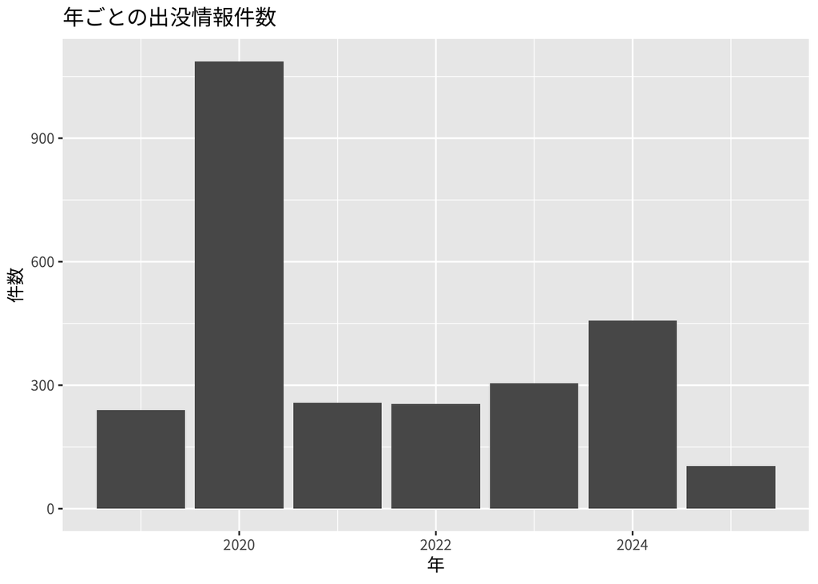

```r
data_bind |>
  dplyr::group_by(Year) |>
  dplyr::tally() |>
  ggplot(aes(x = Year, y = n)) +
  geom_col() +
  labs(title = "年ごとの出没情報件数",
       x = "年",
       y = "件数") +
  theme_gray(base_family = jp_font)
```

### 月別の出没情報件数

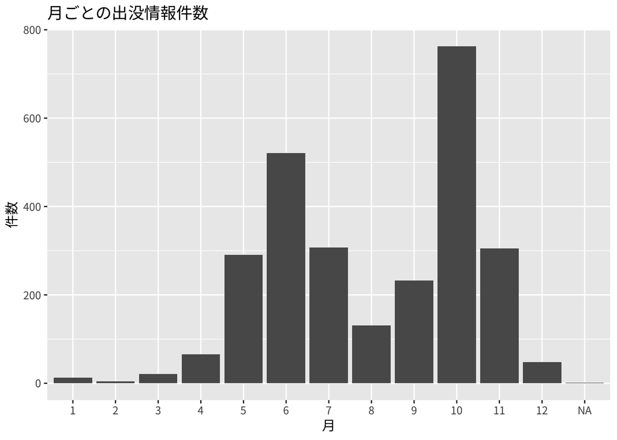

```r
data_bind |>
  dplyr::mutate(Month = as.factor(Month)) |>
  dplyr::group_by(Month) |>
  dplyr::tally() |>
  ggplot(aes(x = Month, y = n)) +
  geom_col() +
  labs(title = "月ごとの出没情報件数",
       x = "月",
       y = "件数") +
  theme_gray(base_family = jp_font)
```

### 時間帯別の出没情報件数

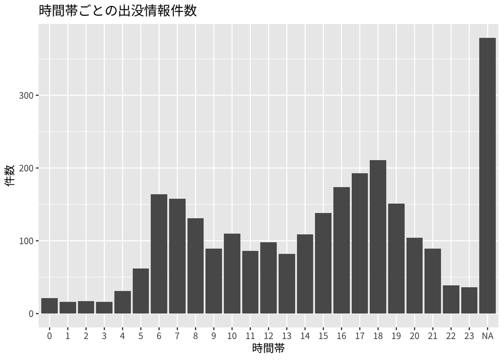

```r
data_bind |>
  dplyr::mutate(Hour = as.factor(Hour)) |>
  dplyr::group_by(Hour) |>
  dplyr::tally() |>
  ggplot(aes(x = Hour, y = n)) +
  geom_col() +
  labs(title = "時間帯ごとの出没情報件数",
       x = "時間帯",
       y = "件数") +
  theme_gray(base_family = jp_font)
```

## 地図上に表示

### Leafletを使用した地図

Leafletを使用して、地図を表示します。デフォルトの地図はOpenStreetMapです。

```r
kuma_map <- leaflet(data = data_bind) |>
  addTiles() |>
  setView(lng = 136.6, lat = 36.7, zoom = 8)
kuma_map
```

[interactive chart not shown]

クマの出没データのある地点にマーカーを置きます。`lng`と`lat`には、`~`をつけて列名を指定します（`leaflet()`に渡したデータの列として評価されます）。

```r
kuma_map |>
  addMarkers(lng = ~Longitude, lat = ~Latitude)
```

[interactive chart not shown]

近いマーカーをクラスター化します。

```r
kuma_map |>
  addMarkers(lng = ~Longitude, lat = ~Latitude,
             clusterOptions = TRUE)
```

[interactive chart not shown]

### 地理院タイル

地図を地理院タイルにすることもできます。利用可能なタイルの種類は以下にあります。

https://maps.gsi.go.jp/development/ichiran.html

ここでは、電子国土基本図（オルソ画像）（2007年～）を地図として表示します。マーカーを円形にして、年ごとに色を変えます。また、マーカーをクリックすると、出没日、時刻、備考が表示されるようにします。

```r
# データ中の年を取得して、昇順に並べ替え
years <- sort(unique(data_bind$Year))

# カラーパレット
# 1の黒はつかわない
# 年数が増えたら、nを増やす
pal_colors <- palette.colors(n = 8, palette = "Okabe-Ito",
                             recycle = TRUE)

leaflet(data = data_bind) |>
  addTiles(urlTemplate = "https://cyberjapandata.gsi.go.jp/xyz/ort/{z}/{x}/{y}.jpg",
           attribution = "<a href='https://maps.gsi.go.jp/development/ichiran.html'>国土地理院</a>") |>
  setView(lng = 136.6, lat = 36.7, zoom = 8) |>
  addCircleMarkers(lng = ~Longitude, lat = ~Latitude,
                   color = ~pal_colors[Year - 2017],
                   opacity = 0.9,
                   fillOpacity = 0.5,
                   radius = 5,
                   weight = 3,
                   popup = ~str_c(Date, Time, Note, sep = " ") |>
                     htmltools::htmlEscape())|>
  addLegend("bottomright",
            colors = unname(pal_colors[years - 2017]),
            labels = years,
            title = "出没年",
            opacity = 0.9)
```

[interactive chart not shown]

拡大してみると、森林と市街地の境界附近で出没情報が多いことがわかります。

## おわりに

### ポイント

- データの確認
  - 表記揺れや入力ミス、その他の間違いのチェック
- 地図上に表示
  - 最初は簡単に
  - だんだん情報を増やしていく